# programming for data analysis

```python
#Student name:angadala surendra
#student id: 20166708
#Module code: CIS7031
#Assessment id: WRIT1
```

```python
#Imports needed for the project

import pandas as pd
import matplotlib.pyplot as plt
from sklearn.cluster import KMeans
from sklearn.preprocessing import StandardScaler
import plotly.express as px
from sklearn.cluster import AgglomerativeClustering
```

[output not shown]

### 1. Data processing

1. Download the dataset for the period 2009 – 2018 and create a dataframe that concatenates Wales (total) employment value only.
2. Check for any null value or outlier. If found replace that with mean value.
3. Change the name of the industries

```python
years = []
industry_names = ["Agriculture","Production","Construction","Retail","ICT","Finance","Real_Estate","Professional_Service","Public_Adminstration","Other_Service"]
data = pd.DataFrame(industry_names,columns=["Industry"])
for i in range(0,10):
    temp = pd.read_csv("./data/export({}).csv".format(i))
    data["20"+str(9+i).rjust(2,"0")] = temp[pd.isnull(temp["Unnamed: 2"])][2:].reset_index()["Wales .1"].astype(float)
    years.append("20"+str(9+i).rjust(2,"0"))
data
```

[output not shown]

```python
# data = pd.read_csv("final-data.csv")
```

### 2. Data analysis

2.1. Which industry employed highest and lowest workers over the period?

```python
data["sum"] = data[data.columns[1:11]].sum(axis=1)
data["avg"] = data[data.columns[1:11]].mean(axis=1)

plt.xticks(rotation='vertical')
plt.ticklabel_format(style = 'plain')
plt.ylabel("No. of  Workers")
plt.bar(data["Industry"],data["sum"])
plt.xticks( rotation=45, horizontalalignment='right')
plt.ylabel("Employees")

plt.show()
```

[output not shown]

### Explanation

To find industry employed the highest and lowest workers over the period

We need to find the total no. of employees employed by each industry in 10 years (2009 - 2018). This can be done by finding the sum of each year for all industries

Here x-axis represents industries and y indicates no. of employees employed

*Public administration* has the highest height

We can conclude that *Public administration* industry has employed highest no. of workers over the span of 10 years

*Real Estate* has the lowest height, therefore

We can also conclude that *Real Estate* industry has employed lowest no. of workers over the span of 10 years

### 2.2. Which industry has the highest and lowest overall growth over the period?

```python
data["Growth"] = (data["2018"] - data["2009"])
plt.xticks(rotation='vertical')
plt.ticklabel_format(style = 'plain')
plt.bar(data["Industry"],data["Growth"])
plt.xticks( rotation=45, horizontalalignment='right')
plt.ylabel("Employees")

plt.show()
```

[output not shown]

### Explanation

Growth can be determined by the difference in Present Value and past value

*Finance* has the lowest height, therefore We can conclude that *Finance* industry has the lowest growth over the span of 10 years

#### 2.3. Which years are the best and worst performing year in relation to number of employment. (highest and lowest employment)

```python
yearSum = data.loc[:,"2009":"2018"].sum()
plt.plot(yearSum.index,yearSum)
plt.xticks(rotation='vertical')
plt.xticks( rotation=45, horizontalalignment='right')
plt.ylabel("Employees")
plt.show()
```

[output not shown]

### Explanation

Number of employees for the year could be found by adding employment for each industry in that appropriate year this will give total the no. of employment per year which can analyze

starting year is neutral and acts as a base for other years any value below the neutral year will be marked as the worst year

The ups and downs of the line represent the best and worst year

Now by interpreting the chart we can conclude the following

**Year 2010** is the worst performing year as line goes below the base year

**Year 2018** is the best performing year as line goes way above the base year

### 3. Visual analysis

```python
# Plot a mutiple y-axis scatter plot
# reshape data to incude 100 records in single column
# and use plotty animation_frame method to create a virtual seperation between year
# Now each Employement is preceded with its Industry and Year
data.index = data["Industry"]
temp = data.drop(columns=["Industry","sum","avg","Growth"])
temp = temp.rename_axis("Years", axis="columns")
plotData = temp.copy()
plotData['Industry'] = plotData.index
plotData = pd.melt(plotData,id_vars = ["Industry"])
plotData = plotData.rename(columns={"value": "Employment", "Years": "Year"})
fig = px.scatter(plotData, x = 'Industry', y = 'Employment', color="Industry", animation_frame="Year", size = 'Employment')
fig.show()
```

[output not shown]

## 4 Correlation

4.1. Taking average employment number for each industry over the period, show and identify the highest and lowest correlated industries.

4.2. Make a year wise correlation for each industry. Does the aforementioned industries are also correlated over the each year? Explain your answer.

```python
data.index = data["Industry"]
temp = data.drop(columns=["Industry","sum","avg","Growth"])
temp = temp.rename_axis("Years", axis="columns")
corr_data = pd.DataFrame(columns=data["Industry"],index=data["Industry"])
for i in corr_data.index:
    corr_data.loc[i] = temp.corrwith(temp.loc[i],axis=1)
corr_data
```

[output not shown]

```python
fig = px.imshow(corr_data,x=corr_data.index,y=corr_data.index)
fig.update_xaxes(side="top")
fig.show()
```

[output not shown]

The Correlation Value is between -1.0 and 1.0

Where 1 indicates Strong Positive Correlation

Where -1 indicates Strong Negative Correlation

By default Pandas uses pearsons method to find the Correlation coefficient

DataFrame **corr_data** represent the data in tabular Form which can be plotted as a Heat Map to make it more readable

**Retail and ICT** is Not Correlated at all i.e. they are negatively Correlated

## 5. Clustering

5.1. Using the best and worst performing year column’s employment data (2.3) undertake a K means clustering analysis (K=2 & 3) and identify industries cluster together. Write your own interpretation (~100 words).

```python
cluster_data = pd.DataFrame(data[["2010","2018","Industry"]])
cluster_data = cluster_data.rename_axis("Year", axis="columns")
cluster_data["Temp_index"] = [i for i in range(0,10)]
```

[output not shown]

```python
# Reshaping for prediction
cluster_data = pd.melt(cluster_data, id_vars = ['Industry', 'Temp_index'])
cluster_data.rename(columns={'value':'Employment'}, inplace=True)
cluster_data.head(5)
```

|  | Industry | Temp_index | Year | Employment |
| --- | --- | --- | --- | --- |
| 0 | Agriculture | 0 | 2010 | 38200.0 |
| 1 | Production | 1 | 2010 | 149800.0 |
| 2 | Construction | 2 | 2010 | 93200.0 |
| 3 | Retail | 3 | 2010 | 344500.0 |
| 4 | ICT | 4 | 2010 | 27900.0 |

## K means clustering - K = 2

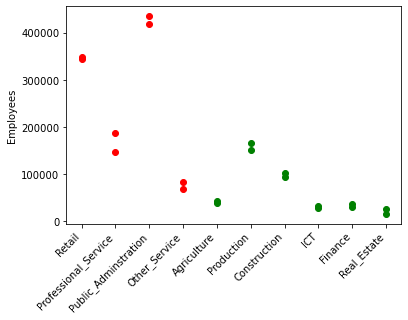

```python
kmeans1 = KMeans(n_clusters=2, init='k-means++', max_iter=300, n_init=10, random_state=0)
kmeans1.fit_predict(StandardScaler().fit_transform(cluster_data.iloc[:,[1,3]]))

K1 = cluster_data[kmeans1.labels_ == 0]# get calculation from cluster via kmeans
K2 = cluster_data[kmeans1.labels_ == 1]

# Scatter both predictions
plt.scatter(K1["Industry"],K1["Employment"], c="red")
plt.scatter(K2["Industry"],K2["Employment"], c="green")
plt.xticks( rotation=45, horizontalalignment='right')
plt.ylabel("Employees")

plt.show()
```

## K means clustering - K = 3

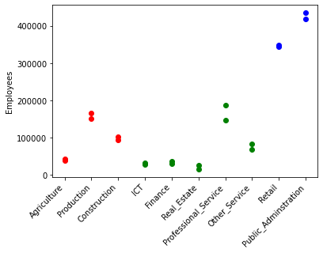

```python
kmeans1 = KMeans(n_clusters=3, init='k-means++', max_iter=300, n_init=10, random_state=0)
kmeans1.fit_predict(StandardScaler().fit_transform(cluster_data.iloc[:,[1,3]]))

K1 = cluster_data[kmeans1.labels_ == 0]# get calculation from cluster via kmeans
K2 = cluster_data[kmeans1.labels_ == 1]
K3 = cluster_data[kmeans1.labels_ == 2]

# Scatter both predictions
plt.scatter(K1["Industry"],K1["Employment"], c="red")
plt.scatter(K2["Industry"],K2["Employment"], c="green")
plt.scatter(K3["Industry"],K3["Employment"], c="blue")
plt.xticks( rotation=45, horizontalalignment='right')
plt.ylabel("Employees")

plt.show()
```

The k-means algorithm searches for a pre-determined number of clusters within a dataset

## Analysis of Graph where K = 2

It Searches for two Cluster Related to each other, Color Specifies the different Cluster

ICT and Retail are negatively correlated so they are in the separate clusters

which we know has the best correlation and creates a stable cluster

**2nd** Cluster contains 6 Industries

## Analysis of Graph where K = 3

It Searches for three Cluster Related to each other, Color Specifies the different Cluster

**2nd** Cluster contains 5 Industries

**3rd** Cluster contains 2 Industries Which also has great Similarity

5.2. Using the same dataset (best & worst performing) create a hierarchical cluster. Compare the cluster with k means clusters.

### Hierarchical cluster - K = 2

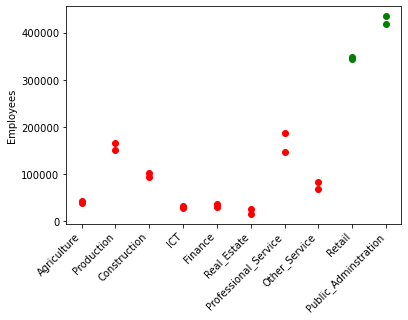

```python
hierarchical_cluster = AgglomerativeClustering(n_clusters=2, affinity='euclidean', linkage ='ward')
hierarchical_cluster.fit_predict(StandardScaler().fit_transform(cluster_data.iloc[:,[1,3]]))

H1 = cluster_data[hierarchical_cluster.labels_ == 0]
H2 = cluster_data[hierarchical_cluster.labels_ == 1]

# Scatter predictions
plt.scatter(H1["Industry"],H1["Employment"], c="red")
plt.scatter(H2["Industry"],H2["Employment"], c="green")
plt.xticks( rotation=45, horizontalalignment='right')
plt.ylabel("Employees")

plt.show()
```

### Hierarchical cluster - K = 3

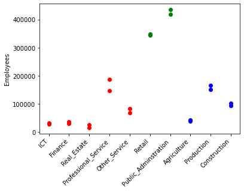

```python
hierarchical_cluster = AgglomerativeClustering(n_clusters=3, affinity='euclidean', linkage ='ward')
hierarchical_cluster.fit_predict(StandardScaler().fit_transform(cluster_data.iloc[:,[1,3]]))

H1 = cluster_data[hierarchical_cluster.labels_ == 0]
H2 = cluster_data[hierarchical_cluster.labels_ == 1]
H3 = cluster_data[hierarchical_cluster.labels_ == 2]

# Scatter predictions
plt.scatter(H1["Industry"],H1["Employment"], c="red")
plt.scatter(H2["Industry"],H2["Employment"], c="green")
plt.scatter(H3["Industry"],H3["Employment"], c="blue")
plt.xticks( rotation=45, horizontalalignment='right')
plt.ylabel("Employees")
plt.show()
```

### Discussion

We have analyzed data of Wales using Different techniques such as bar plots, line chart, clustering and Correlating

Each chart Provided us with relevant information about the relationship between each industry and How they affect each other over the course of 10 years ( 2009 - 2018 )

Starting with the bar plots we can see there is steady and positive overall development over the year. Employment Number varies for each Industries

Public Administration Industry has the Largest No. of Employees. Which benefits the citizens of **Wales** by providing them a reliable Administration Industry

Professional Service such as architects, accountants, engineers, doctors, and lawyers. Also shows a Steady Growth and Most maximum Growth when compared to other industries

*Negatively Impacted industries*

1. Real_estate and ICT has the Lowest amount of workers in 10 years
2. ICT and Finance has the second Lowest amount of workers in 10 years
3. Finance Industry has the lowest Growth when compared to other industries
4. 2010 is the worst year as Employment of each industry was dropped Significantly and 2018 show the most Employment

We have used **Pearson's** method to find the Correlation coefficient. It returns a value between **-1** and **+1**

**Agricultural, Estates and Administration** industries correlates with every other country

**Agriculture, Production, Construction** industries are very closely related and Are present in Every Cluster we have analyzed. Deflection in Employment for one industry can affect Employment no. of other industries

Different Clustering techniques show the same picture of the cluster. Although it can be seen that the hierarchical approach is better and more accurate for our dataset as it recognizes correct no. of employees